# 543 Lab 1

Emelie

November 15, 2023

# Probability Sampling

We won’t be covering this in detail until Tuesday’s lecture, however I think/hope the notation and results are straightforward enough to follow prior. If I’m wrong, don’t spend too much focus on the lab until after Tuesday’s lecture is reviewed!

This lab will compare the sampling methods:

- Simple random sampling without replacement (SRSWOR)
- Simple random sampling with replacement (SRSWR)

We will be interested in $\mu$ and $\sigma^2$, i.e. the ``true” population mean and variance. For both SRSWOR and SRSWR use the following estimators:

- $\tilde{\mu} = \frac{1}{n}\sum\limits_{i\in S} y_i$
- $\tilde{\sigma}^2 = \frac{1}{n-1}\sum\limits_{i \in S} (y_i - \tilde{\mu})^2$

where S is a random sample with $P(S = s)$ defined by our sampling protocol. Note: estimates are fixed values, estimators are random variables.

In this lab we will “show” the following result for SRSWOR
$$\begin{equation}\label{eq:WOR}
E\left[ \tilde{\mu } \right] = \mu, \quad\quad\mbox{and} \quad\quad
Var \left ( \tilde{\mu } \right ) = \left( 1 - \frac{n}{N}
\right) \frac{\sigma^2 }{n}
\end{equation}$$
and for SRSWR
$$\begin{equation}\label{eq:WR}
E\left[\tilde{\mu} \right] = \mu \quad\quad\mbox{and} \quad\quad
Var(\tilde{\mu}) = \left(1 - \frac{1}{N}\right)\frac{\sigma^2}{n}
\end{equation}$$
That is, we will verify that the (empirical) distribution of $\tilde \mu$ is centered close to $\mu$ and that the variance of the mean estimator is larger for SRSWR than for SRSWOR.

# Data

For this lab we will be using a data set comprised of the weights and perimeters of 100 wooden blocks. The attribute of interest to us is the block weights. To begin, let’s read in the `Blocks` data:

```r
blocks = read.csv("Blocks.csv", header=TRUE)
nrow(blocks) # should be 100 data points
```

```
## [1] 100
```

```r
head(blocks)
```

```
##   Block Weights Perimeter
## 1     1      77      41.3
## 2     2      42      36.0
## 3     3      44      33.0
## 4     4      33      28.6
## 5     5      62      40.3
## 6     6      34      34.6
```

```r
attach(blocks) # so we can call the attributes by name
```

# Population Parameters

We will treat the complete set of 100 blocks as our **target population**. As we have the complete set of weights for these blocks, we can calculate the true population average `Weights` and look at the distribution in a histogram:

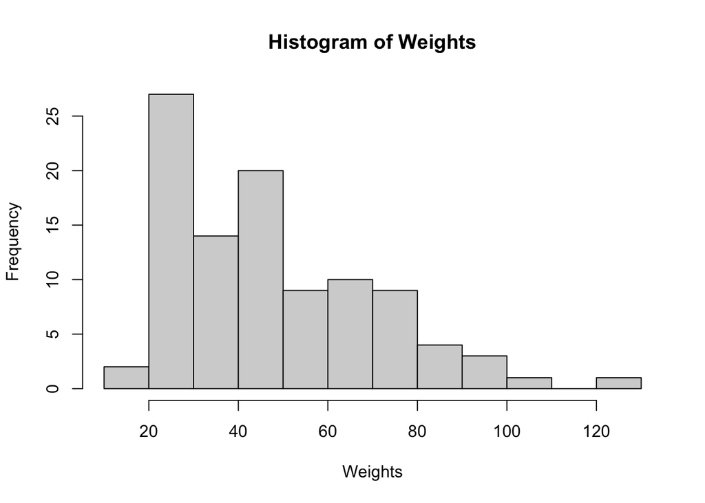

```r
mu_w = mean(Weights)
hist(Weights)
```

We can do the similar calculations for `Perimeter`.

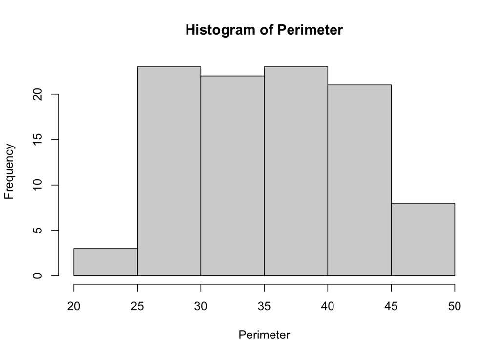

```r
mu_p = mean(Perimeter)
hist(Perimeter)
```

The mean weight is 47.94 and the average perimeter is 35.389. As one might expect, the bigger the perimeter, the more weight a block will have. This relationship, made apparent in the scatterplot below, will be used in a future lab.

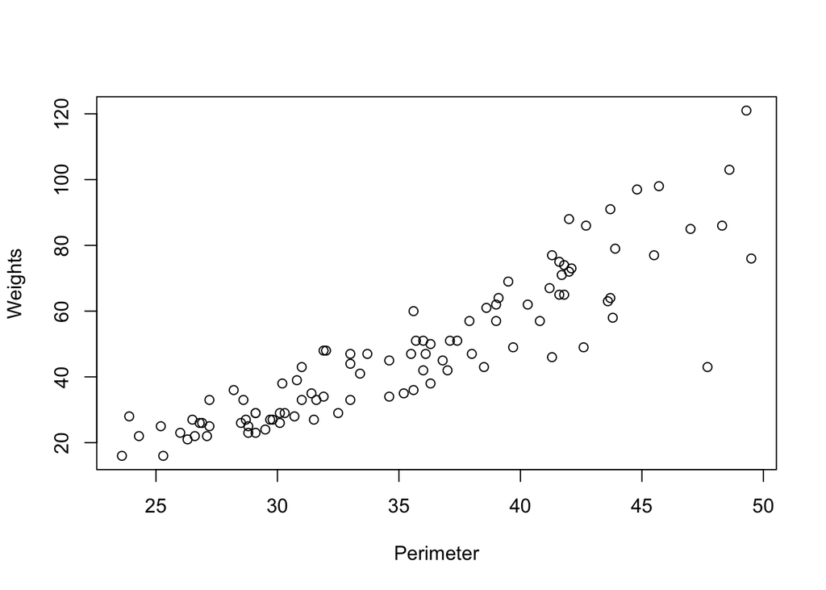

```r
plot(Perimeter, Weights)
```

Let’s consider a simple random sample without replacement (SRSWOR) of size $n=10$ taken from the set of 100 blocks. To make the results reproducible, we will set a seed equal to the course number in DATA 543:

```r
set.seed(543)
sample1 = sample(1:100, n)
```

As can be seen in the details of `sample` (see `?sample`), the default functionality is to sample without replacement, i.e. `replace=FALSE` by default. To tie this in with the set notation presented in class:

- $U =\{1, 2, \dots, 99, 100\}$
- $s = 99, 86, \dots, 15, 60$ taken from `sample1` above.

The sample average and sample standard deviation of the weights can be calculated as follows:

```r
wbar = mean(Weights[sample1])
wsd = sd(Weights[sample1])
```

Hence $\hat{\mu} =$ 39 and $s_{w} =$ 16.61.

# SRSWR

As an exercise, complete the same as above for a simple random sample with replacement (SRSWR). You can find the solution in the Rmd file.

# Simulation Study

Now lets consider a SRSWR and a SRSWOR of size $n= 5, 10, 15,$ and 20. For each sample size we will consider 10000 replications (called `M` in the code provided below.) Again, we are interested in the average `Weights`. We will hold the results for each replication/sample size using SRSWOR and SRSWR in a matrix called `z1` and `z2`, respectively.

```r
M = 10^4
n = c(5, 10, 15, 20)
names(n) = paste("n", n, sep="=")
# store the results for a SRSWOR
z1 = matrix(0, nrow=M, ncol=length(n))
# store the results for a SRSWR
z2 = matrix(0, nrow=M, ncol=length(n))
colnames(z1) = colnames(z2) = paste("n", n, sep="=")
for (i in 1:M) {
  for (j in 1:length(n)) {

  sample1  = sample(1:100, n[j])
  sample2  = sample(1:100, n[j], replace=TRUE)

  ## the sample averages
  ybar1 = mean(Weights[sample1])
  ybar2 = mean(Weights[sample2])

  z1[i,j] = ybar1
  z2[i,j] = ybar2
  }
}
```

Display the empirical estimate of the sampling distribution. We will superimpose the true value of $\mu$ (in red)

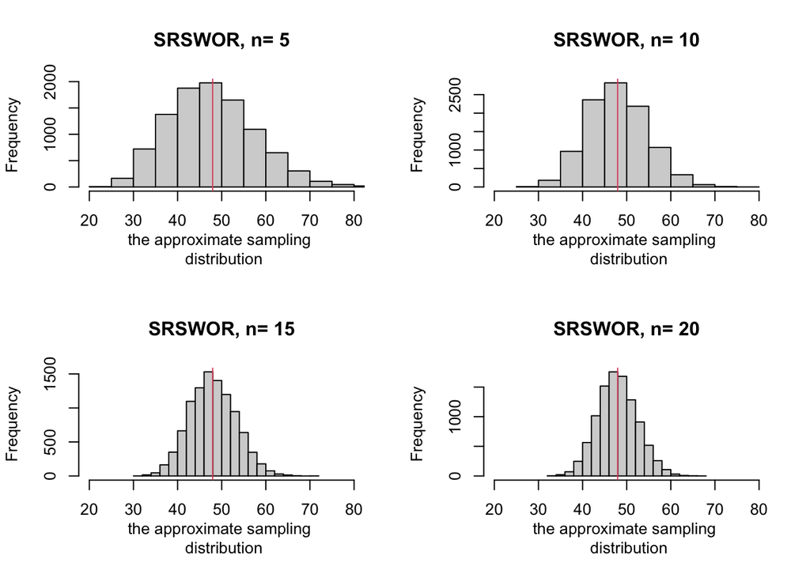

```r
par(mfrow=c(2,2))
for (j in 1:4) {
  hist(z1[,j], main= paste("SRSWOR, n=", n[j]) , xlim=c(20,80),
       xlab="the approximate sampling \n distribution")
  abline(v=mu_w, col=2) # compare with the true value
}
```

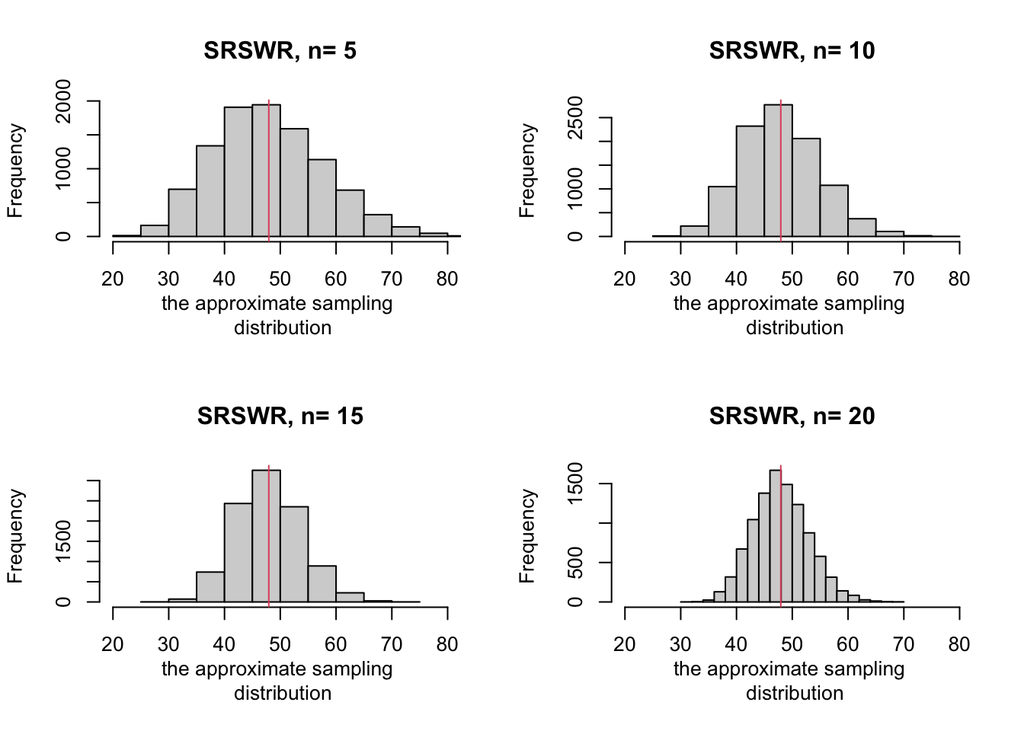

```r
par(mfrow=c(2,2))
for (j in 1:4) {
  hist(z2[,j], main= paste("SRSWR, n=", n[j]) , xlim=c(20,80),
       xlab="the approximate sampling \n distribution")
  abline(v=mu_w, col=2) # compare with the true value
}
```

In can be shown that $\hat{\mu}$ is an unbaised estimate of $\mu$, ie. $E[\tilde{\mu}] = \mu$. It is therefore unsurprising that the true value is very close to the empirical distribution means:

```r
round(apply(z1,2,mean),3)
```

```
##    n=5   n=10   n=15   n=20
## 47.863 47.933 48.003 47.950
```

```r
round(apply(z2,2,mean),3)
```

```
##    n=5   n=10   n=15   n=20
## 48.083 47.883 47.936 47.975
```

```r
mu_w
```

```
## [1] 47.94
```

As mentioned in the introduction, the estimator for the mean using SRSWOR is more efficient than that for SRSWR. To see if this hold true in the empirical distribution, lets compare the variance of each of the estimators.

```r
round( apply(z1,2,var),2) # variance of muhat using SRSWOR
```

```
##   n=5  n=10  n=15  n=20
## 95.63 44.57 27.11 20.15
```

```r
round( apply(z2,2,var),2) # variance of muhat using SRSWR
```

```
##   n=5  n=10  n=15  n=20
## 98.53 48.67 33.72 24.69
```

Notice how the variance of $\hat \mu_{SRSWOR}$ is smaller than the variance of $\hat \mu_{SRSWR}$ for all $n = (5, 10, 15, 20)$. As a final step, lets compare the variance calculated on the empirical distribution with the theoretical distribution.

```r
round((1-n/100)*var(Weights)/n, 2) # variance of muhat using SRSWOR
```

```
##   n=5  n=10  n=15  n=20
## 94.01 44.53 28.04 19.79
```

```r
round((1-1/100)*var(Weights)/n, 2) # variance of muhat using SRSWR
```

```
##   n=5  n=10  n=15  n=20
## 97.96 48.98 32.65 24.49
```

# From Lecture 2

I’ll throw these in void of commentary as it is the code used to generate examples in Lecture!

```r
set.seed(543)
library(randomNames)
names <- randomNames(100)
programs <- c("Accounting", "Physics", "History", "Arts", "Chemistry", "Electrical Engineering", "Mechanical Engineering", "Civil Engineering", "Computer Science", "Economics", "French", "Geography", "Journalism", "Economics", "Law", "Nursing", "Mathematics", "Statistics", "Sociology", "Music")
program <- sample(rep(programs, each=5))
englcourse <- sample(rep(c("ENGL 100 001","ENGL 100 002", "ENGL 100 003", "ENGL 100 004", "ENGL 100 005"), each=20))
classList <- data.frame(names,program,englcourse)


#########################
# SRSWOR
#########################

set.seed(543)
# to sample their position in the list:
sample(100, 20)
```

```
##  [1] 99 86 62  4 39 94 69 19 15 60 23 21 97 76  5 59 22 79 47 36
```

```r
# to sample them by name:
head(classList)
```

```
##                     names           program   englcourse
## 1     Glammeyer, Jonathan           History ENGL 100 001
## 2 French-Stegall, Antonio       Mathematics ENGL 100 001
## 3       Francis, Cheyenne              Arts ENGL 100 001
## 4           Zuni, Michael Civil Engineering ENGL 100 004
## 5      Vialpando, Lesslie Civil Engineering ENGL 100 005
## 6         Shirali, Alayna         Geography ENGL 100 004
```

```r
sample(classList$names, 20)
```

```
##  [1] "Lobatos, Ivan"     "Leyba, Elaine"     "Hamilton, Curtis"
##  [4] "Juarez, Malyssa"   "Lampe, Kevin"      "el-Yacoub, Hadeel"
##  [7] "Vang, Sae"         "Gamble, Jaurdane"  "French, Brian"
## [10] "al-Raad, Mu'taz"   "Goetsch, Ivy"      "Howard, Marcus"
## [13] "Pushchak, Ashwini" "el-Daoud, Sanad"   "el-Tariq, Hamad"
## [16] "Deo'Compos, Nina"  "Feaster, Mary"     "Sanchez, Malika"
## [19] "al-Rafiq, Noori"   "Mbugua, Ajana"
```

```r
#########################
# Stratified Sampling
#########################

# divides the data into the groups defined by program
byProgram <- split(classList, program)

# since we want a sample of size 20 and there are 20 programs, we need to sample 1 person from each program
stratSamp <- lapply(byProgram, function(x) sample(x$names,1))

#########################
# Cluster Sampling
#########################
byCourse <- split(classList, englcourse)
sampCourse <- as.character(sample(unique(classList$englcourse),1))
byCourse[sampCourse]
```

```
## $`ENGL 100 001`
##                      names                program   englcourse
## 1      Glammeyer, Jonathan                History ENGL 100 001
## 2  French-Stegall, Antonio            Mathematics ENGL 100 001
## 3        Francis, Cheyenne                   Arts ENGL 100 001
## 7        Lancaster, Joseph                History ENGL 100 001
## 17         Boisselle, Lane             Statistics ENGL 100 001
## 25        Gamble, Jaurdane                Nursing ENGL 100 001
## 27           Lomeli, Erica                 French ENGL 100 001
## 35            Xiao, Joshua              Chemistry ENGL 100 001
## 37      al-Quadri, Faseeha                Nursing ENGL 100 001
## 39     Ginsberg, Chuan-Kun                  Music ENGL 100 001
## 47              Walby, Jeb              Geography ENGL 100 001
## 53        Vargas, Veronica              Sociology ENGL 100 001
## 56            Goetsch, Ivy                  Music ENGL 100 001
## 59         al-Raad, Mu'taz       Computer Science ENGL 100 001
## 61       Nelson III, Seeta Mechanical Engineering ENGL 100 001
## 69         Gregory, Hunter              Chemistry ENGL 100 001
## 83          Powell, Isaiha                History ENGL 100 001
## 89        Brungard, Travis Electrical Engineering ENGL 100 001
## 92       Shaheen, Jeremiah                   Arts ENGL 100 001
## 96           Baik, Abigail             Journalism ENGL 100 001
```

```r
#########################
# Systematic Sampling
#########################

# start at 2 and take every 5th one thereafter
clustSampB <- seq(from=2, to =100, by = 5)
clustSampB
```

```
##  [1]  2  7 12 17 22 27 32 37 42 47 52 57 62 67 72 77 82 87 92 97
```

```r
classList$names[clustSampB]
```

```
##  [1] "French-Stegall, Antonio"  "Lancaster, Joseph"
##  [3] "Stanley, Aaron"           "Boisselle, Lane"
##  [5] "Ortiz Johnson, Zaira"     "Lomeli, Erica"
##  [7] "Malik, Hoangcung"         "al-Quadri, Faseeha"
##  [9] "al-Dallal, Abdul Ghafoor" "Walby, Jeb"
## [11] "Deo'Compos, Nina"         "Tiger, Destiny"
## [13] "Lightfoot, Shania"        "Sides, Kyle"
## [15] "Sanchez, Malika"          "Lobatos, Ivan"
## [17] "Juarez, Malyssa"          "Pushchak, Ashwini"
## [19] "Shaheen, Jeremiah"        "el-Tariq, Jadeeda"
```